# Part II - (Data Analysis for Fordgobike dataset)

## by (Celestial Afrane)

## Investigation Overview

My main interest for this analysis was to identify some patterns and make some predictions. In case any bike company wants to sell or provide bike products/activity to san francisco area, their target market should focus more of Men Between the age of 25 to 40 Also, they like to be subscribers as compared to been a regular customer.

Also, they drive more on saturdays and sundays because its weekendsI(majority of the riders are in the working class)

In general, san francisco area is a good community for any bike company to make business profits.Highly recommended.

## Dataset Overview

This data set includes information about individual rides made in a bike-sharing system covering the greater San Francisco Bay area.

## (Visualization 1/Gender Count

From our visualization, we want to know the count for gender. I realised there are more male riders in san francisco area compared to females and others

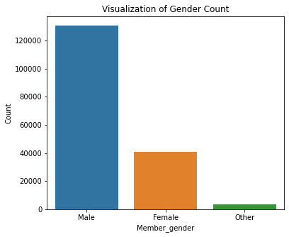

## (Visualization 2/User Type Count

From the analysis, I wanted to find out the count for user_type. From the analysis I have more subscribers than regular customers.Which means san francisco people like riding bikes

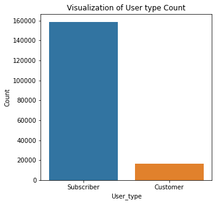

## (Visualization 3/Age Range

From the analysis, I wanted to know the age range I realised frequent riders are between 25 to 40 years .

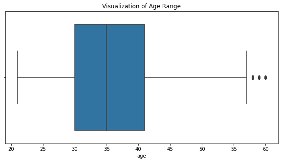